# analyzeGrade

Bao Trau Nhiep

4/22/2021

```r
library(readxl)
library(tidyverse)
```

# Import file Excel vào R để xử lí - midTerm

```r
midGrade <- read_excel("E:\\R Project\\201_CO1007.xlsx", sheet = 2, range = "A5:AB162")
glimpse(midGrade)
```

```
## Rows: 157
## Columns: 28
## $ No   <dbl> 1, 40, 30, 24, 28, 9, 10, 3, 2, 7, 4, 8, 5, 6, 34, 29, 38, 23, 22~
## $ MANH <chr> "L02", "L02", "L01", "L01", "L01", "L02", "L02", "L02", "L02", "L~
## $ TO   <chr> "A", "B", "A", "A", "A", "A", "A", "A", "A", "A", "A", "A", "A", ~
## $ `1`  <dbl> 1, 0, 1, 1, 1, 1, 1, 1, 1, 1, 1, 1, 1, 1, 1, 1, 1, 1, 1, 1, 1, 1,~
## $ `2`  <dbl> 0, 1, 0, 0, 1, 1, 1, 0, 0, 0, 1, 0, 0, 1, 0, 0, 1, 0, 0, 1, 1, 0,~
## $ `3`  <dbl> 1, 0, 0, 0, 1, 1, 0, 0, 0, 0, 0, 0, 1, 1, 0, 0, 0, 0, 0, 1, 0, 0,~
## $ `4`  <dbl> 0, 1, 1, 1, 1, 1, 1, 1, 1, 0, 1, 1, 1, 1, 1, 0, 1, 0, 1, 1, 1, 1,~
## $ `5`  <dbl> 0, 1, 0, 0, 1, 1, 1, 0, 0, 1, 1, 1, 0, 0, 1, 0, 0, 1, 1, 0, 0, 0,~
## $ `6`  <dbl> 0, 1, 0, 0, 1, 1, 1, 1, 0, 1, 1, 1, 0, 1, 0, 0, 1, 0, 1, 1, 1, 1,~
## $ `7`  <dbl> 1, 0, 0, 1, 0, 1, 1, 1, 0, 0, 0, 1, 1, 1, 1, 0, 1, 1, 1, 1, 0, 0,~
## $ `8`  <dbl> 1, 1, 1, 1, 1, 1, 1, 1, 0, 1, 1, 1, 1, 1, 1, 1, 0, 1, 0, 1, 0, 1,~
## $ `9`  <dbl> 0, 1, 0, 0, 1, 0, 0, 0, 0, 0, 0, 0, 0, 0, 1, 0, 0, 0, 0, 0, 1, 0,~
## $ `10` <dbl> 1, 0, 0, 1, 1, 1, 1, 0, 0, 0, 0, 0, 0, 1, 0, 0, 1, 0, 1, 0, 0, 0,~
## $ `11` <dbl> 1, 1, 1, 1, 1, 0, 1, 1, 1, 1, 1, 1, 1, 1, 1, 1, 1, 1, 1, 1, 1, 1,~
## $ `12` <dbl> 0, 0, 0, 0, 0, 1, 0, 0, 0, 0, 1, 0, 1, 1, 0, 0, 0, 0, 1, 0, 0, 1,~
## $ `13` <dbl> 1, 1, 0, 0, 1, 1, 0, 1, 1, 0, 1, 1, 1, 1, 0, 0, 0, 0, 0, 1, 1, 0,~
## $ `14` <dbl> 0, 0, 1, 1, 0, 0, 1, 0, 1, 0, 1, 1, 0, 1, 0, 0, 0, 0, 1, 0, 0, 1,~
## $ `15` <dbl> 0, 0, 0, 0, 0, 0, 0, 0, 0, 0, 0, 0, 0, 0, 0, 0, 0, 0, 0, 0, 0, 0,~
## $ `16` <dbl> 1, 1, 1, 0, 1, 1, 1, 1, 1, 0, 1, 1, 1, 1, 1, 0, 1, 1, 1, 1, 1, 1,~
## $ `17` <dbl> 0, 1, 1, 0, 1, 1, 0, 0, 1, 1, 1, 1, 0, 1, 1, 1, 1, 0, 1, 1, 1, 1,~
## $ `18` <dbl> 1, 1, 1, 1, 1, 1, 1, 1, 1, 1, 1, 1, 1, 1, 1, 1, 0, 1, 1, 1, 1, 1,~
## $ `19` <dbl> 1, 0, 0, 0, 1, 1, 1, 1, 0, 0, 1, 1, 1, 1, 0, 1, 1, 1, 1, 1, 0, 1,~
## $ `20` <dbl> 0, 1, 0, 0, 1, 1, 1, 0, 1, 1, 0, 1, 1, 1, 0, 0, 0, 1, 0, 1, 0, 0,~
## $ `21` <dbl> 1, 1, 1, 0, 1, 1, 1, 1, 1, 1, 1, 1, 0, 1, 1, 0, 1, 0, 0, 1, 1, 1,~
## $ `22` <dbl> 0, 0, 1, 0, 0, 0, 1, 0, 0, 1, 0, 1, 1, 1, 0, 0, 0, 0, 0, 1, 1, 1,~
## $ `23` <dbl> 1, 1, 0, 1, 1, 1, 1, 1, 0, 1, 1, 1, 1, 1, 1, 0, 0, 0, 1, 0, 0, 1,~
## $ `24` <dbl> 0, 0, 0, 0, 1, 1, 0, 1, 1, 0, 1, 1, 1, 1, 1, 0, 0, 1, 1, 0, 1, 1,~
## $ `25` <dbl> 0, 1, 0, 1, 1, 1, 0, 0, 1, 1, 0, 0, 1, 1, 1, 1, 1, 1, 1, 1, 0, 0,~
```

# Import file Excel vào R để xử lí - finalTerm

```r
finalGrade <- read_excel("E:\\R Project\\201_CO1007.xlsx", sheet = 4, range = "A5:AO168")
glimpse(finalGrade)
```

```
## Rows: 163
## Columns: 41
## $ No   <dbl> 1, 2, 3, 4, 5, 6, 7, 8, 9, 10, 11, 12, 13, 14, 15, 16, 17, 18, 19~
## $ MANH <chr> "L01", "L01", "L01", "L01", "L01", "L01", "L01", "L01", "L01", "L~
## $ TO   <chr> "A", "A", "A", "A", "A", "A", "A", "A", "A", "A", "A", "A", "A", ~
## $ `1`  <dbl> 0, 1, 1, NA, 1, 1, 1, 1, 0, 0, 1, 1, 1, NA, 1, 0, 0, 1, 1, 0, 0, ~
## $ `2`  <dbl> 0, 0, 1, NA, 0, 0, 0, 1, 0, 0, 0, 0, 0, NA, 0, 0, 0, 0, 0, 0, 1, ~
## $ `3`  <dbl> 1, 1, 1, NA, 1, 0, 1, 1, 1, 0, 1, 1, 1, NA, 1, 0, 0, 1, 1, 0, 0, ~
## $ `4`  <dbl> 0, 1, 1, NA, 1, 1, 1, 1, 1, 1, 0, 1, 1, NA, 0, 1, 1, 1, 1, 0, 1, ~
## $ `5`  <dbl> 0, 1, 0, NA, 1, 1, 0, 1, 1, 0, 1, 1, 0, NA, 1, 1, 1, 1, 1, 0, 1, ~
## $ `6`  <dbl> 1, 1, 1, NA, 1, 0, 1, 0, 0, 1, 0, 1, 0, NA, 0, 1, 1, 1, 1, 0, 1, ~
## $ `7`  <dbl> 1, 0, 1, NA, 1, 1, 1, 0, 0, 0, 1, 1, 1, NA, 1, 1, 1, 0, 1, 1, 0, ~
## $ `8`  <dbl> 1, 1, 1, NA, 1, 0, 0, 0, 0, 1, 1, 0, 0, NA, 1, 0, 1, 1, 1, 0, 0, ~
## $ `9`  <dbl> 1, 0, 1, NA, 1, 1, 1, 0, 1, 0, 1, 0, 0, NA, 0, 1, 0, 0, 1, 1, 1, ~
## $ `10` <dbl> 0, 1, 0, NA, 1, 1, 1, 0, 1, 0, 1, 1, 0, NA, 1, 1, 0, 1, 1, 1, 1, ~
```

[output cut: 28 more lines]

```r
finalGrade[is.na(finalGrade)] = 0
```

# Chuẩn bị dữ liệu điểm của sinh viên trong tập GKI

**Cách thực hiện:** Tính tổng số các câu đúng, sau đó tính được điểm của các sinh viên.  
*Bảng điểm Giữa kì của sinh viên*

```r
#Computing How many true answer
midSeq <- rowSums(select(midGrade, `1`:`25`) == 1)

#Computing Grade
midMark <- round((midSeq / 25) * 10, 2)
midMark
```

```
##   [1] 4.8 6.0 4.0 4.0 8.0 8.0 6.8 5.2 4.8 4.8 6.8 7.2 6.4 8.8 5.6 2.8 4.8 4.4
##  [19] 6.4 6.8 5.2 6.0 6.0 5.2 6.4 4.4 4.0 6.4 6.8 6.8 6.0 6.0 6.4 5.2 6.8 5.2
##  [37] 6.4 5.2 7.2 3.6 5.6 6.0 6.4 6.0 7.6 5.6 6.8 4.4 8.4 8.4 6.4 5.6 6.0 4.8
##  [55] 6.8 7.2 4.8 3.6 4.8 6.0 5.2 8.0 4.4 4.4 6.4 5.2 6.8 5.6 4.8 5.2 6.0 5.2
##  [73] 5.6 8.0 4.8 6.4 5.6 5.2 5.2 4.8 7.6 6.8 5.6 4.8 3.6 4.8 7.2 6.0 7.2 5.6
##  [91] 4.8 6.8 4.4 6.4 4.8 2.0 6.8 5.2 6.0 4.8 7.2 6.0 3.6 8.0 7.2 4.0 2.8 4.0
## [109] 4.4 5.2 6.0 6.8 2.4 5.2 5.6 6.0 8.0 6.0 3.2 3.2 3.6 5.6 4.4 6.4 8.0 6.4
## [127] 5.6 6.8 6.4 4.8 6.0 6.4 4.0 7.2 6.4 8.0 6.8 4.0 5.6 5.6 6.4 7.2 6.8 7.2
## [145] 3.6 6.4 2.8 7.2 6.8 4.8 6.0 4.4 6.0 3.2 5.2 3.6 5.2
```

# Chuẩn bị dữ liệu điểm của sinh viên trong tập CKI

*Bảng điểm Cuối kì của sinh viên*

```r
#Computing How many true answer
finalSeq <- rowSums(select(finalGrade, `1`:`38`) == 1)

#Computing Grade
finalMark <- round((finalSeq / 38) * 10, 2)
finalMark
```

```
##   [1] 3.95 7.37 6.05 0.00 7.63 5.79 4.47 3.16 4.21 4.74 7.37 6.05 5.00 0.00 4.47
##  [16] 6.05 6.32 5.79 8.68 4.21 3.68 6.58 8.42 7.63 7.37 4.74 8.42 6.05 6.32 3.68
##  [31] 7.89 5.00 5.53 6.05 6.84 3.95 7.63 3.95 6.32 0.00 5.26 7.37 7.37 0.00 4.21
##  [46] 7.37 6.05 0.00 8.42 5.79 5.53 4.21 0.00 6.32 7.37 6.32 5.53 5.00 0.00 4.74
##  [61] 0.00 7.63 4.74 8.68 3.42 8.16 3.95 6.32 3.68 6.84 8.16 6.05 8.95 7.37 6.58
##  [76] 8.68 6.58 5.53 5.53 5.79 6.05 7.37 4.21 7.63 6.84 8.42 8.42 7.11 5.79 8.68
##  [91] 8.42 7.63 5.00 8.42 8.68 7.63 7.63 6.58 7.11 6.32 7.37 7.89 6.84 6.05 5.79
## [106] 6.84 8.68 7.37 5.79 7.37 5.79 7.89 4.47 7.37 5.00 6.32 6.32 5.00 8.16 6.84
## [121] 0.00 6.05 5.79 8.95 6.58 7.63 7.37 8.42 8.42 0.00 0.00 7.63 8.16 6.05 8.42
## [136] 6.05 6.84 0.00 5.53 6.84 3.42 8.42 8.95 6.32 7.37 7.11 6.84 2.11 9.21 5.79
## [151] 0.00 4.47 6.32 7.89 8.95 6.32 0.00 6.58 7.63 4.47 4.21 3.68 5.26
```

# Câu 1

**Yêu cầu đề:** Tính trung vị mẫu, cực đại mẫu, cực tiểu mẫu giữa kỳ và mẫu cuối kỳ  
**Cách thực hiện:** Dùng các hàm median, max và min cho dữ liệu điểm giữa kì và cuối kì.  
*Trung vị mẫu Giữa kì*

```r
options(digits = 3)
median(midMark)
```

```
## [1] 5.6
```

*Cực đại mẫu Giữa kì*

```r
max(midMark)
```

```
## [1] 8.8
```

*Cực tiểu mẫu Giữa kì*

```r
min(midMark)
```

```
## [1] 2
```

*Trung vị mẫu Cuối kì*

```r
median(finalMark)
```

```
## [1] 6.32
```

*Cực đại mẫu Cuối kì*

```r
max(finalMark)
```

```
## [1] 9.21
```

*Cực tiểu mẫu Cuối kì*

```r
min(finalMark)
```

```
## [1] 0
```

# Câu 2 -> 4

**Yêu cầu đề:** Đếm các sinh viên mà điểm của mỗi sinh viên trong tập mẫu giữa kỳ và mẫu cuối kỳ lớn hơn hoặc bằng 9 -> 5  
**Cách thực hiện:** Dựa trên bảng dữ liệu điểm Giữa kì và Cuối kì, lọc ra các mức điểm thỏa điều kiện đề.  
*Số sinh viên có điểm Giữa kì lớn hơn hoặc bằng 9*

```r
sum(midMark >= 9)
```

```
## [1] 0
```

*Số sinh viên có điểm Giữa kì lớn hơn hoặc bằng 7*

```r
sum(midMark >= 7)
```

```
## [1] 24
```

*Số sinh viên có điểm Giữa kì lớn hơn hoặc bằng 5*

```r
sum(midMark >= 5)
```

```
## [1] 109
```

*Số sinh viên có điểm Cuối kì lớn hơn hoặc bằng 9*

```r
sum(finalMark >= 9)
```

```
## [1] 1
```

*Số sinh viên có điểm Cuối kì lớn hơn hoặc bằng 7*

```r
sum(finalMark >= 7)
```

```
## [1] 59
```

*Số sinh viên có điểm Cuối kì lớn hơn hoặc bằng 5*

```r
sum(finalMark >= 5)
```

```
## [1] 122
```

# Câu 5

**Yêu cầu đề:** Đếm các sinh viên mà điểm của mỗi sinh viên trong tập mẫu nhỏ hơn 5  
**Cách thực hiện:** Dựa trên bảng dữ liệu điểm trong tập mẫu, lọc ra các mức điểm nhỏ hơn 5.

```r
sum(midMark < 5) + sum(finalMark < 5)
```

```
## [1] 89
```

# Câu 6

**Yêu cầu đề:** Vẽ biểu đồ phổ điểm của sinh viên trong tập mẫu giữa kỳ và mẫu cuối kỳ.  
**Cách thực hiện:** Dùng hàm Hist để vẽ biểu đồ Histogram (dạng biểu đồ thể hiện tần suất ở dạng cột) thể hiện phổ điểm của sinh viên trong tập giữa kì và cuối kì.  
*Phổ điểm Giữa kì*

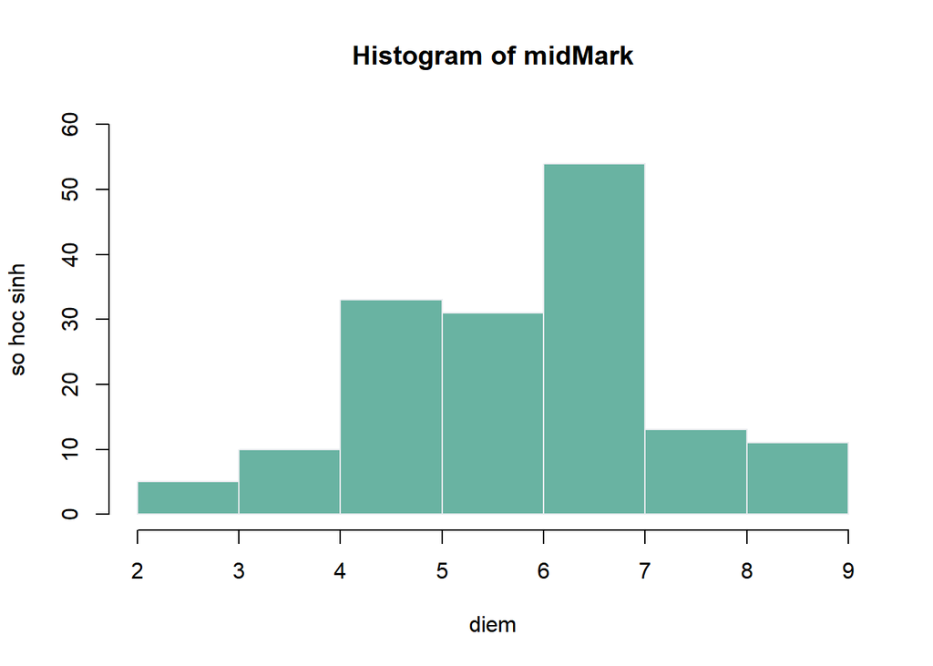

```r
hist(midMark, col ="#69b3a2", right = FALSE, border = "#e9ecef", xlab = "diem", ylab = "so hoc sinh", ylim = c(0,60))
```

*Phổ điểm Cuối kì*

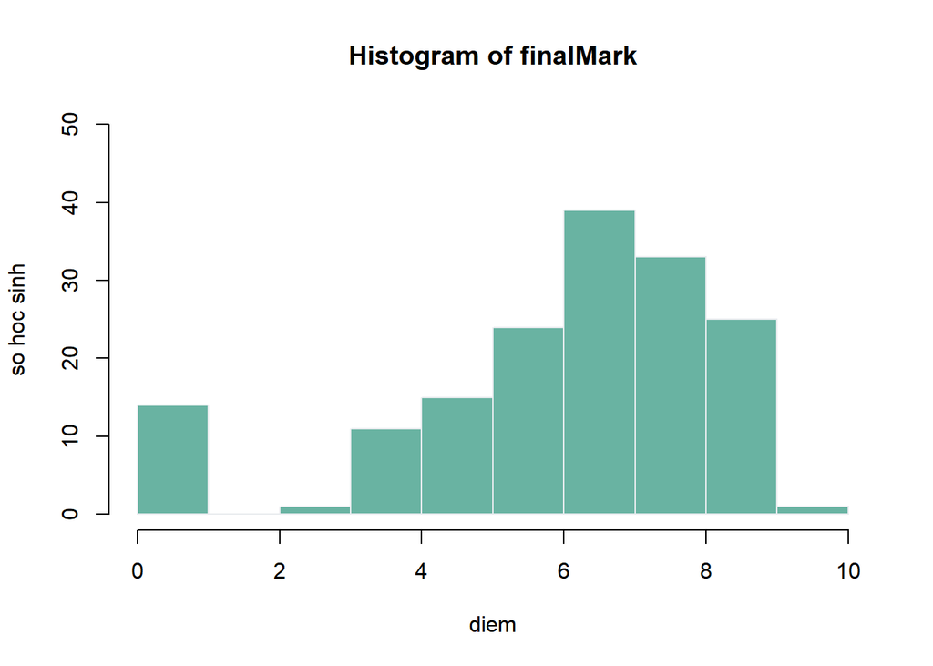

```r
hist(finalMark, col ="#69b3a2", right = FALSE, border = "#e9ecef", xlab = "diem", ylab = "so hoc sinh", ylim = c(0,50))
```

# Câu 7 - 8

**Yêu cầu đề:** Xác định danh sách sinh viên gồm số thứ tự (No), mã nhóm và tổ có điểm số lớn nhất hoặc nhỏ nhất trong tập mẫu giữa kỳ và mẫu cuối kỳ **Cách thực hiện:** Kết hợp sử dụng các hàm filter, min và max trên bảng dữ liệu để lọc ra danh sách sinh viên (gồm các thông tin: số thứ tự, mã nhóm và tổ) có điểm số lớn nhất và nhỏ nhất trong tập mẫu giữa kỳ và cuối kỳ.  
*Danh sách sinh viên có điểm số lớn nhất Giữa kỳ*

```r
midGrade <- mutate(midGrade, grade = midMark)
finalGrade <- mutate(finalGrade, grade = finalMark)
filter(select(midGrade, No, MANH, TO, grade), midGrade$grade == max(midMark))
```

```
## # A tibble: 1 x 4
##      No MANH  TO    grade
##   <dbl> <chr> <chr> <dbl>
## 1     6 L02   A       8.8
```

*Danh sách sinh viên có điểm số nhỏ nhất Giữa kỳ*

```r
filter(select(midGrade, No, MANH, TO, grade), midGrade$grade == min(midMark))
```

```
## # A tibble: 1 x 4
##      No MANH  TO    grade
##   <dbl> <chr> <chr> <dbl>
## 1   104 L01   A         2
```

*Danh sách sinh viên có điểm số lớn nhất Cuối kỳ*

```r
filter(select(finalGrade, No, MANH, TO, grade), finalGrade$grade == max(finalMark))
```

```
## # A tibble: 1 x 4
##      No MANH  TO    grade
##   <dbl> <chr> <chr> <dbl>
## 1   149 L02   B      9.21
```

*Danh sách sinh viên có điểm số nhỏ nhất Cuối kỳ*

```r
filter(select(finalGrade, No, MANH, TO, grade), finalGrade$grade == min(finalMark))
```

```
## # A tibble: 14 x 4
##       No MANH  TO    grade
##    <dbl> <chr> <chr> <dbl>
##  1     4 L01   A         0
##  2    14 L01   A         0
##  3    40 L01   B         0
##  4    44 L01   B         0
##  5    48 L01   B         0
##  6    53 L01   B         0
##  7    59 L01   B         0
##  8    61 L01   B         0
##  9   121 L02   A         0
## 10   130 L02   B         0
## 11   131 L02   B         0
## 12   138 L02   B         0
## 13   151 L02   B         0
## 14   157 L02   B         0
```

# VI. 4

**Yêu cầu đề:** Các nhóm làm bài tốt như nhau hay một nhóm làm bài tốt hơn ở cuối kỳ? Hãy đưa ra lý do cho câu trả lời của bạn.  
**Cách thực hiện:** Dựa trên độ phổ điểm của các sinh viên trong nhóm (thể hiện tương quan hình học, cho cái nhìn tổng quan về sự phân bố sinh viên ở những mốc điểm khác nhau), cùng với điểm trung bình(đánh giá tổng quát về điểm số của từng nhóm) và trung vị(đánh giá hiệu quả hơn về điểm số trong trường hợp dữ liệu bị phân tán) của một nhóm để so sánh mức độ làm bài của các nhóm.

*Nhóm 1A*

```r
index_1A <- (finalGrade$MANH == "L01" & finalGrade$TO == "A")
average_1A <- mean(finalGrade$grade[index_1A])
average_1A
```

```
## [1] 5.57
```

```r
median(finalGrade$grade[index_1A])
```

```
## [1] 6.05
```

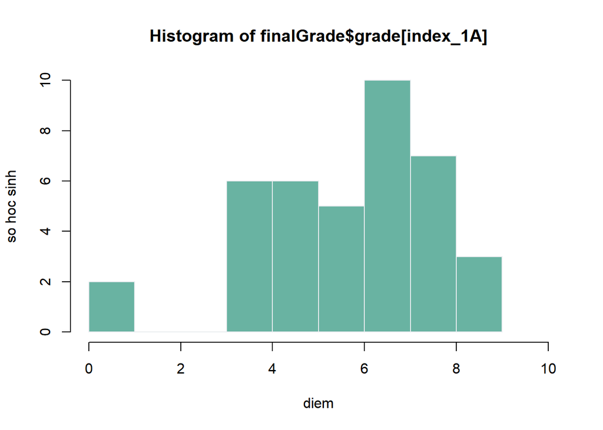

```r
h_1A <- hist(finalGrade$grade[index_1A], col ="#69b3a2", right = FALSE, border = "#e9ecef", xlab = "diem", ylab = "so hoc sinh", ylim = c(0,10), xlim = c(0,10))
```

Phổ điểm của nhóm 1A dạng bảng

```r
roundDens <- round(h_1A$density, 2)
data.frame(
   mocDiem = c("0 -> 1", "1 -> 2","2 -> 3","3 -> 4","4 -> 5", "5 -> 6","6 -> 7","7 -> 8" ,"8 -> 9"),
   soLuong = h_1A$counts,
   matDo = roundDens)
```

```
##   mocDiem soLuong matDo
## 1  0 -> 1       2  0.05
## 2  1 -> 2       0  0.00
## 3  2 -> 3       0  0.00
## 4  3 -> 4       6  0.15
## 5  4 -> 5       6  0.15
## 6  5 -> 6       5  0.13
## 7  6 -> 7      10  0.26
## 8  7 -> 8       7  0.18
## 9  8 -> 9       3  0.08
```

*Nhóm 1B*

```r
index_1B <- (finalGrade$MANH == "L01" & finalGrade$TO == "B")
average_1B <- mean(finalGrade$grade[index_1B])
average_1B
```

```
## [1] 5.42
```

```r
median(finalGrade$grade[index_1B])
```

```
## [1] 6.05
```

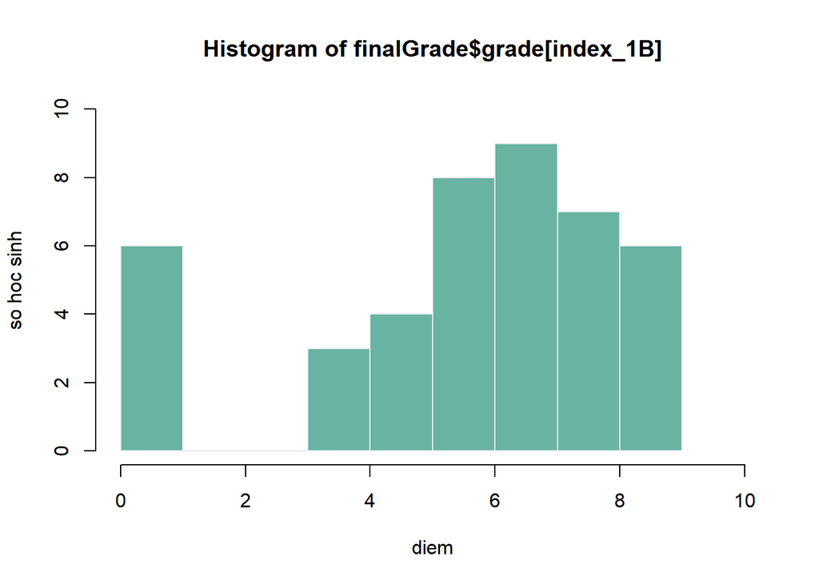

```r
h_1B <-hist(finalGrade$grade[index_1B], col ="#69b3a2", right = FALSE, border = "#e9ecef", xlab = "diem", ylab = "so hoc sinh", ylim = c(0,10), xlim = c(0,10))
```

Phổ điểm của nhóm 1B dạng bảng

```r
roundDens <- round(h_1B$density, 2)
data.frame(
  mocDiem = c("0 -> 1", "1 -> 2","2 -> 3","3 -> 4","4 -> 5", "5 -> 6","6 -> 7","7 -> 8" ,"8 -> 9"),
  soLuong = h_1B$counts,
  matDo = roundDens)
```

```
##   mocDiem soLuong matDo
## 1  0 -> 1       6  0.14
## 2  1 -> 2       0  0.00
## 3  2 -> 3       0  0.00
## 4  3 -> 4       3  0.07
## 5  4 -> 5       4  0.09
## 6  5 -> 6       8  0.19
## 7  6 -> 7       9  0.21
## 8  7 -> 8       7  0.16
## 9  8 -> 9       6  0.14
```

*Nhóm 2A*

```r
index_2A <- (finalGrade$MANH == "L02" & finalGrade$TO == "A")
average_2A <- mean(finalGrade$grade[index_2A])
average_2A
```

```
## [1] 6.74
```

```r
median(median(finalGrade$grade[index_2A]))
```

```
## [1] 6.97
```

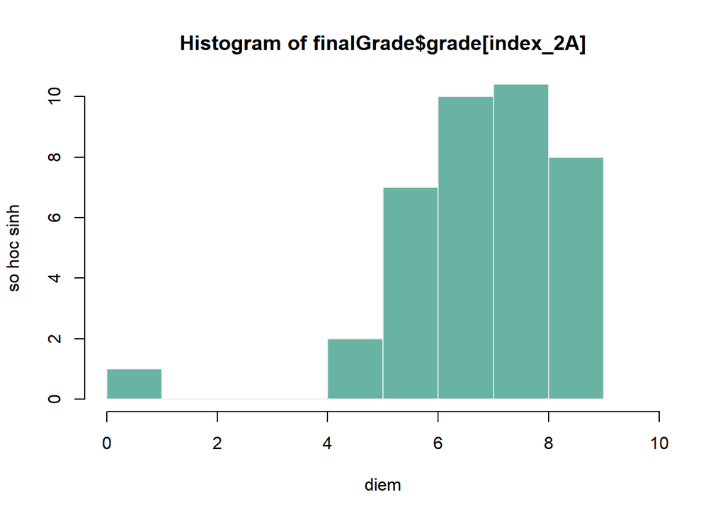

```r
h_2A <-hist(finalGrade$grade[index_2A], col ="#69b3a2", right = FALSE, border = "#e9ecef", xlab = "diem", ylab = "so hoc sinh", ylim = c(0,10), xlim = c(0,10))
```

Phổ điểm của nhóm 2A dạng bảng

```r
roundDens <- round(h_2A$density, 2)
data.frame(
  mocDiem = c("0 -> 1", "1 -> 2","2 -> 3","3 -> 4","4 -> 5", "5 -> 6","6 -> 7","7 -> 8" ,"8 -> 9"),
  soLuong = h_2A$counts,
  matDo = roundDens)
```

```
##   mocDiem soLuong matDo
## 1  0 -> 1       1  0.03
## 2  1 -> 2       0  0.00
## 3  2 -> 3       0  0.00
## 4  3 -> 4       0  0.00
## 5  4 -> 5       2  0.05
## 6  5 -> 6       7  0.17
## 7  6 -> 7      10  0.25
## 8  7 -> 8      12  0.30
## 9  8 -> 9       8  0.20
```

*Nhóm 2B*

```r
index_2B <- (finalGrade$MANH == "L02" & finalGrade$TO == "B")
average_2B <- mean(finalGrade$grade[index_2B])
average_2B
```

```
## [1] 5.85
```

```r
median(median(finalGrade$grade[index_2B]))
```

```
## [1] 6.58
```

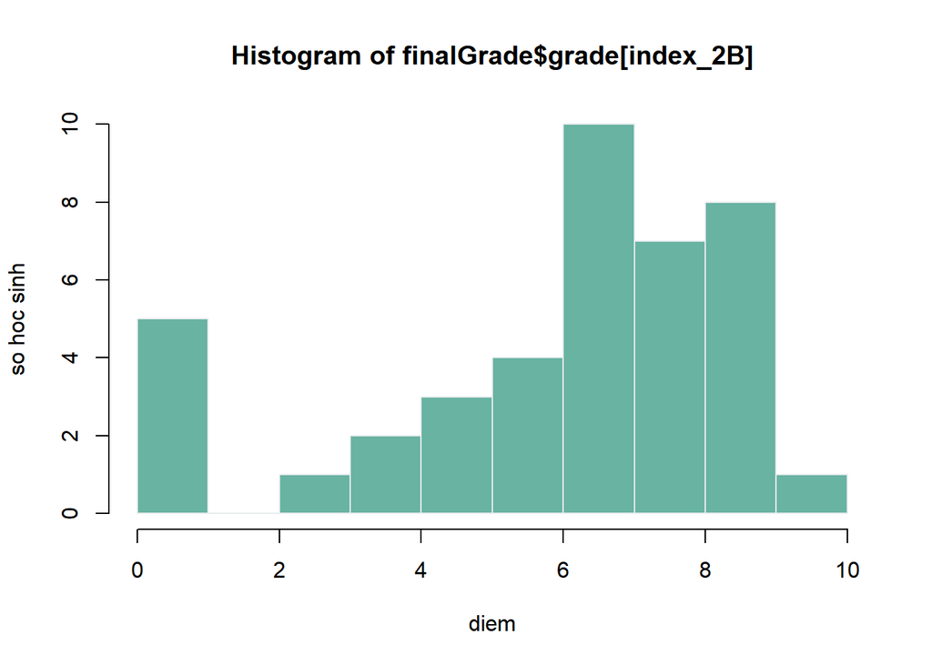

```r
h_2B <-hist(finalGrade$grade[index_2B], col ="#69b3a2", right = FALSE, border = "#e9ecef", xlab = "diem", ylab = "so hoc sinh", ylim = c(0,10), xlim = c(0,10))
```

Phổ điểm của nhóm 2B dạng bảng

```r
roundDens <- round(h_2B$density, 2)
data.frame(
  mocDiem = c("0 -> 1", "1 -> 2","2 -> 3","3 -> 4","4 -> 5", "5 -> 6","6 -> 7","7 -> 8" ,"8 -> 9", "9 -> 10"),
  soLuong = h_2B$counts,
  matDo = roundDens)
```

```
##    mocDiem soLuong matDo
## 1   0 -> 1       5  0.12
## 2   1 -> 2       0  0.00
## 3   2 -> 3       1  0.02
## 4   3 -> 4       2  0.05
## 5   4 -> 5       3  0.07
## 6   5 -> 6       4  0.10
## 7   6 -> 7      10  0.24
## 8   7 -> 8       7  0.17
## 9   8 -> 9       8  0.20
## 10 9 -> 10       1  0.02
```